# Relatório sobre salários de TI

José Lucas Albuquerque de Andrade

30/08/2020

## Introdução

Para esse relatório foi usado os seguintes conceitos de estatística descritiva: média, mediana, quartil, moda e gráficos descritivos. Foi utilizada a base de dados FuncionariosTI disponibilizada pelo professor Rivanilson S. Rodrigues, com o objetivo de encontrar o máximo possivel de informações sobre a mesma, observando as seguintes colunas: UF, experiência profissional e tempo de empresa.

## Análise

A partir da filtragem da região de cada desenvolvedor, encontra-se a seguinte proporção:

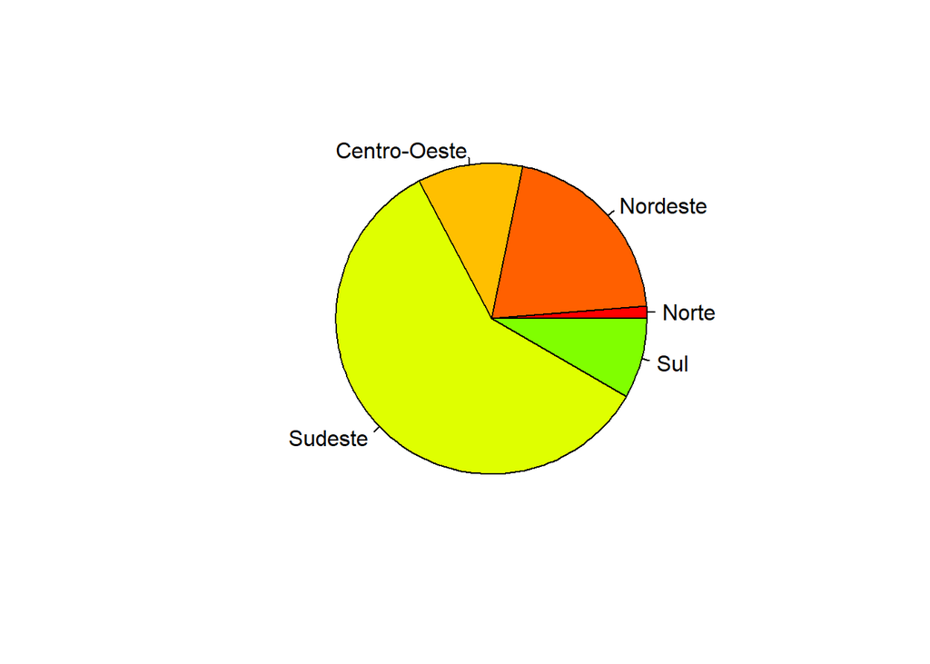

**Figura 1 - Porcentagem de funcionários por região.**

Sumário de dados dos salários por região :

**Norte**

```
##    Min. 1st Qu.  Median    Mean 3rd Qu.    Max.
##    1105    1829    2552    2552    3276    4000
```

```
## [1] "Variância:  4190512.5"
```

```
## [1] "Desvio Padrão:  2047.07413153506"
```

**Nordeste**

```
##    Min. 1st Qu.  Median    Mean 3rd Qu.    Max.
##     700    1975    2650    3104    4150    6300
```

```
## [1] "Variância:  2390552.93447581"
```

```
## [1] "Variância Padrão:  1546.14130482172"
```

**Centro-Oeste**

```
##    Min. 1st Qu.  Median    Mean 3rd Qu.    Max.
##    1200    3990    4769    4637    5500    8000
```

```
## [1] "Variância:  3019868"
```

```
## [1] "Variância Padrão:  1737.77674055098"
```

**Sudeste**

```
##    Min. 1st Qu.  Median    Mean 3rd Qu.    Max.
##     500    2294    3583    3962    5500    9500
```

```
## [1] "Variância:  3912797.53255017"
```

```
## [1] "Variância Padrão:  1978.07925335416"
```

**Sul**

```
##    Min. 1st Qu.  Median    Mean 3rd Qu.    Max.
##    1800    3100    3500    3658    4500    5495
```

```
## [1] "Variância:  1017182.93589744"
```

```
## [1] "Variância Padrão:  1008.55487500554"
```

Com a base de dados também é possivel visualizar a moda, distribuição salarial e a frequência absoluta em cada estado:

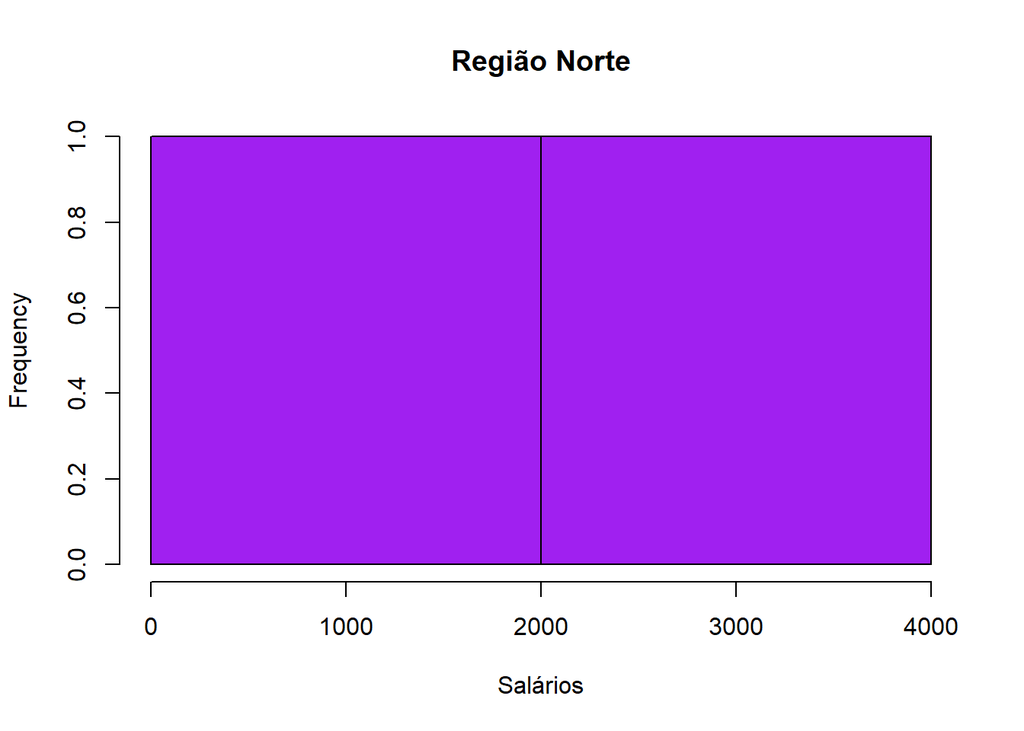

**Figura 2 - Salários da região norte e moda**

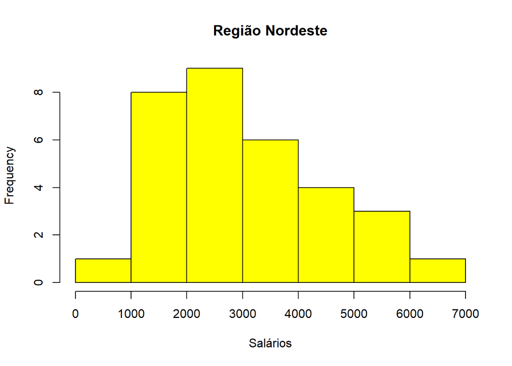

**Figura 3 - Salários da região nordeste e moda**

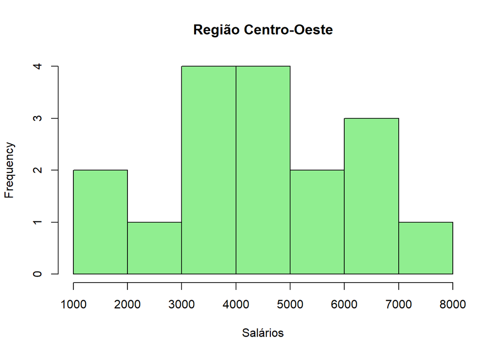

**Figura 4 - Salários da região centro-Oeste e moda**

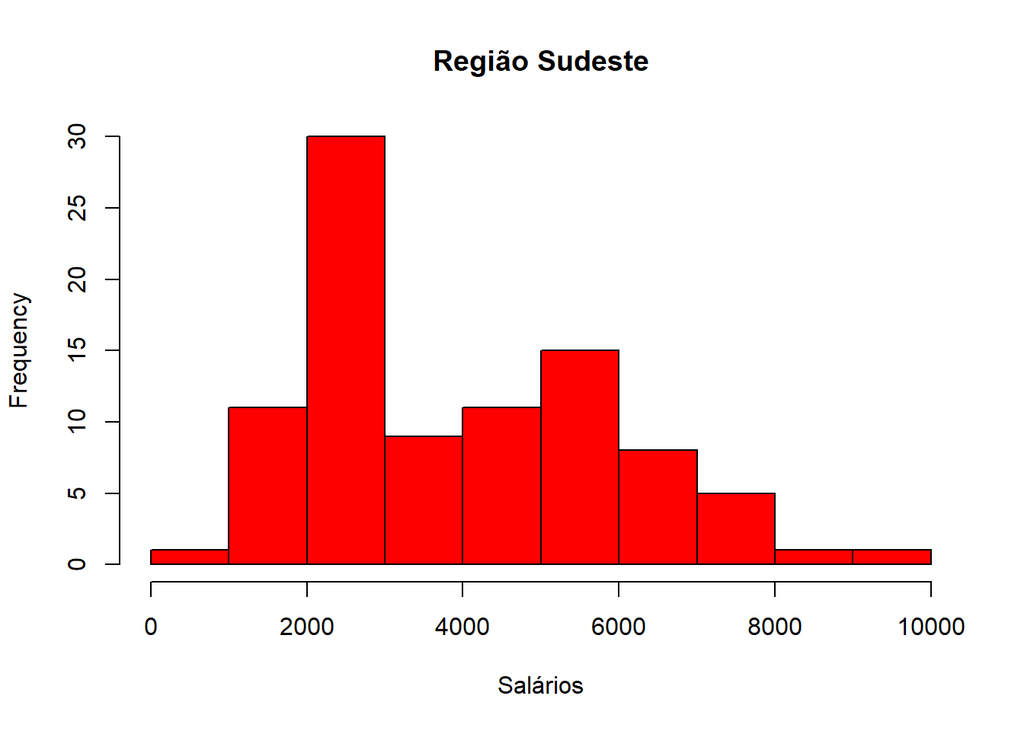

**Figura 5 - Salários da região sudeste e moda**

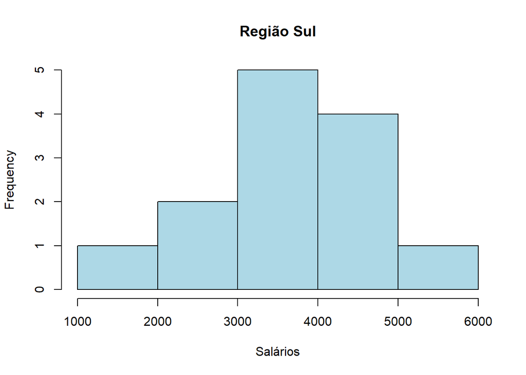

**Figura 6 - Salários da região sul e moda**

A seguir podemos ver a mediana dos salários a partir do tempo de empresa que seus colaboradores possuem, sendo que funcionários com mais de 6 anos foram omitidos, pois foram encontrados apenas 5 na região sudeste.

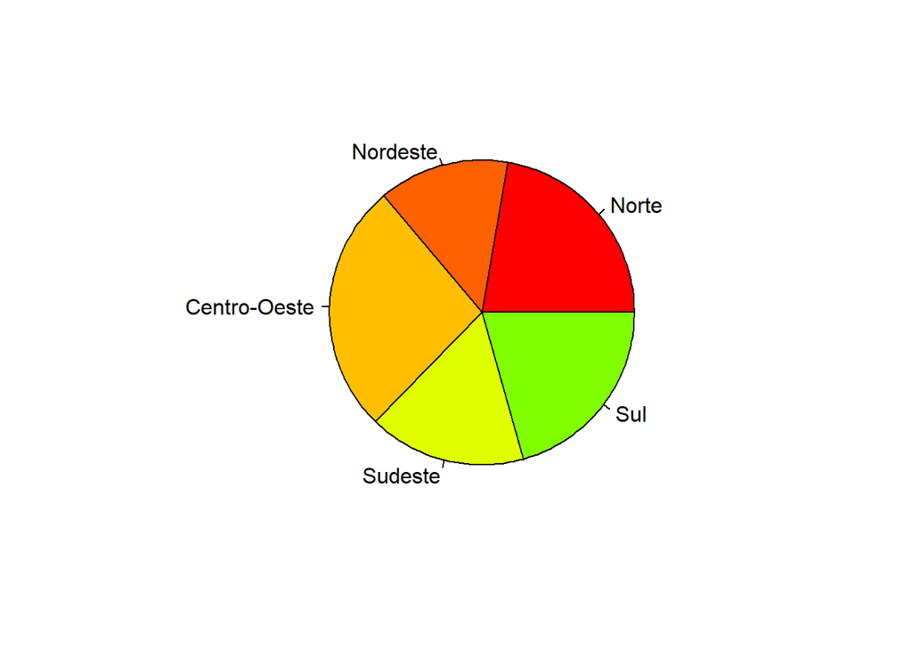

**Figura 7 - Mediana salarial com até 3 anos de tempo de empresa**

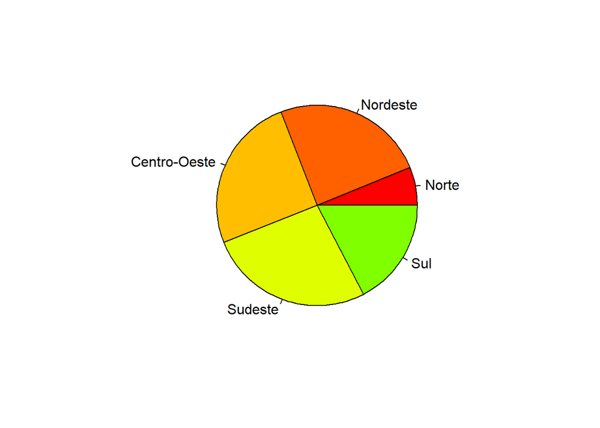

**Figura 8 - Mediana salarial de 3 até 6 anos de tempo de empresa**

E com o ultimo parâmetro temos os seguintes gráficos de acordo com a experiência profissional:

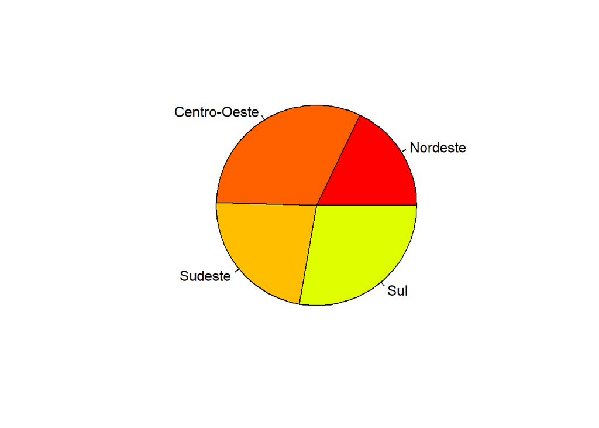

**Figura 9 - Mediana salarial de até 5 anos de experiência profissional**

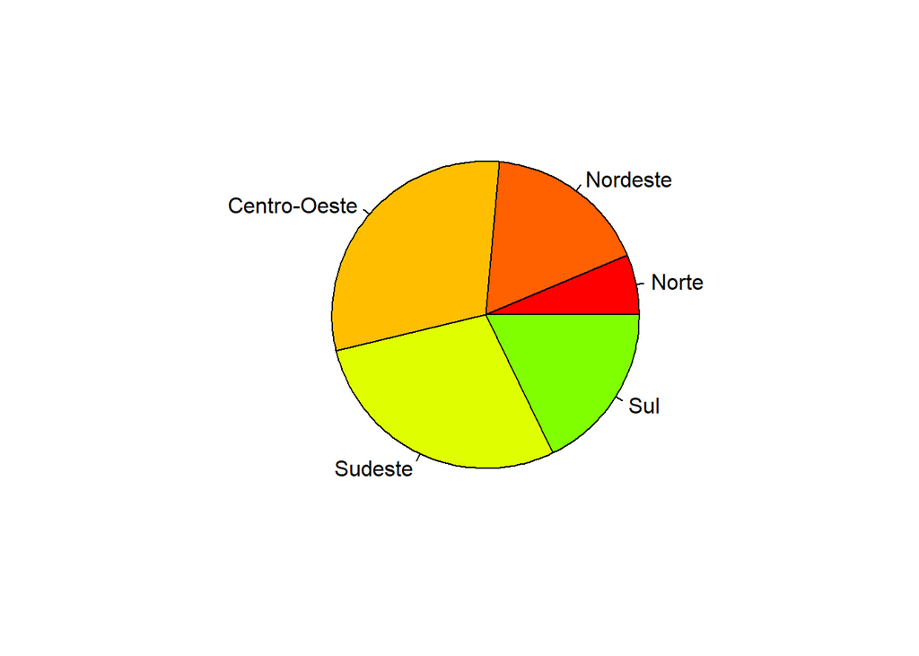

**Figura 10 - Mediana salarial de 5 até 10 anos de experiência profissional**

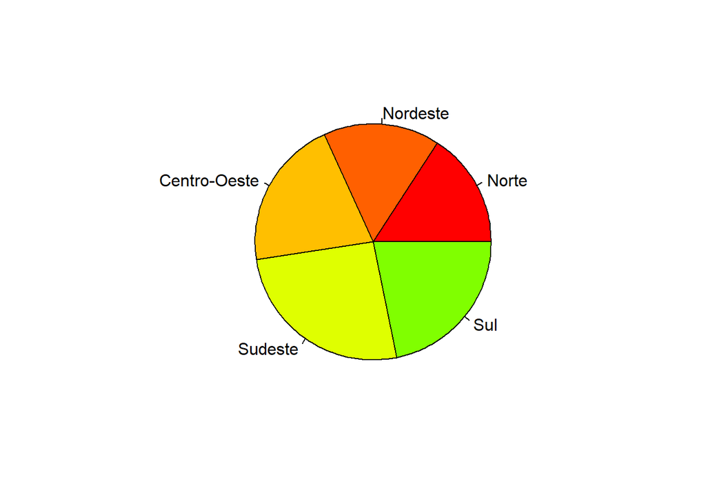

**Figura 11 - Mediana salarial de 10 até 15 anos de experiência profissional**

## Conclusão

Após a análise na base de dados pode-se tirar as seguintes conclusões:

- A maioria dos funcionários é da região sudeste, seguido pelo nordeste.
- A mediana apresenta uma melhor medida, exceto na região norte.
- A uma grande variância padrão nos salários das regiões como constatado, sendo o mais aceitavel da região sul.
- Todas as regiões apresenta uma moda salarial entre 2.000 e 5.000 reais, exceto na região norte.
- Os estados sudeste e nordeste apresentam uma mediana salarial menor em comparado aos outros em até 3 anos de tempo de empresa.
- Os estados norte e sul apresentam uma mediana salarial menor em comparado aos outros em até 6 anos de tempo de empresa.
- Com de 5 até 10 anos de tempo de experiência os funcionários do centro-Oeste são mais bem pagos, seguidos pelo sudeste.